# Projekt Inteligencja Obliczeniowa

Justyna Sarkowicz, Olga Sieradzan, Weronika Duda, Amelia Madej, Aleksandra Węgrzyn

2025-01-15

# Wprowadzenie

**Problem komiwojażera** (ang. Travelling Salesman Problem, TSP) to jedno z najbardziej znanych oraz intensywnie badanych zagadnień w dziedzinie optymalizacji kombinatorycznej oraz teorii grafów. W swojej klasycznej formie problem ten polega na znalezieniu najkrótszej możliwej trasy, która odwiedza dokładnie raz każdy z zadanych punktów i powraca do punktu początkowego. TSP znajduje zastosowanie w wielu dziedzinach, takich jak logistyka, planowanie tras, produkcja czy genetyka.

TSP jest problemem należącym do klasy NP-trudnych, co oznacza, że wraz ze wzrostem liczby punktów (miast) liczba możliwych tras rośnie w sposób wykładniczy, a dokładne rozwiązanie staje się coraz trudniejsze do obliczenia w rozsądnym czasie. Z tego powodu opracowuje się efektywne algorytmy heurystyczne i metaheurystyczne, które umożliwiają znalezienie rozwiązań zbliżonych do optymalnych w akceptowalnym czasie.

Celem naszego projektu jest implementacja sześciu różnych algorytmów, które rozwiązują problem komiwojażera.

# Solver

Wyniki uzyskane za pomocą zaimplementowanych algorytmów zostaną porównane z tymi uzyskanymi w Solverze. Będzie to nasz benchmark.

| TSP_48_CZAS | TSP_76_CZAS | TSP_127_CZAS |
| --- | --- | --- |
| 140.406 | 150.797 | 210.266 |
| 102.547 | 44.937 | 232.140 |
| 93.188 | 43.344 | 238.906 |
| 136.828 | 47.313 | 229.453 |
| 102.547 | 47.047 | 230.094 |
| 92.625 | 198.063 | 192.000 |

W przypadku danych TSP_48 czasy są tutaj dość zbliżone. Najniższy z nich to 92.625 s. Natomiast dla TSP_76 mamy dwie wartości znacząco odstające od pozostałych. Dla TSP_127 czasy są zdecydowanie najdłuższe w stosunku do pozostałych. Nie ma tam tak rozbieżnych wyników jak dla TSP_76.

## Statystyki

W statystykach poniżej przedstawiono najkrótszą oraz najdłuższą długość ścieżki uzyskaną przez Solver. Mamy również wyznaczoną średnią ze wszystkich wyników.

|  | min | max | mean |
| --- | --- | --- | --- |
| TSP_48 | 10868.0 | 11568.0 | 11154.67 |
| TSP_76 | 118293.5 | 150779.9 | 139999.45 |
| TSP_127 | 140217.6 | 146646.1 | 143436.97 |

Będzie to nasz benchmark, do którego będziemy odnosić wyniki uzyskane przez pozostałe algorytmy.

# Algorytmu Najbliższego Sąsiada (NN)

**Algorytm najbliższego sąsiada** (ang. nearest neighbour algorithm, NN) jest prostym algorytmem służącym do rozwiązania prolemu komiwojażera. Jego celem jest znalezienie najkrótszej trasy, która przechodzi przez wszystkie miasta. Proces rozpoczyna się od wybranego miasta, a następnie w każdym kroku wybierane jest najbliższe miasto, które jeszcze nie zostało odwiedzone, do którego algorytm przechodzi. Po odwiedzeniu wszystkich miast algorytm kończy działanie i zwraca uzyskaną trasę.

## Badane parametry

W ramach algorytmu nalbliższego sąsiada badaniu poddano wpływ różnych wartości parametru `miasto startowe`.

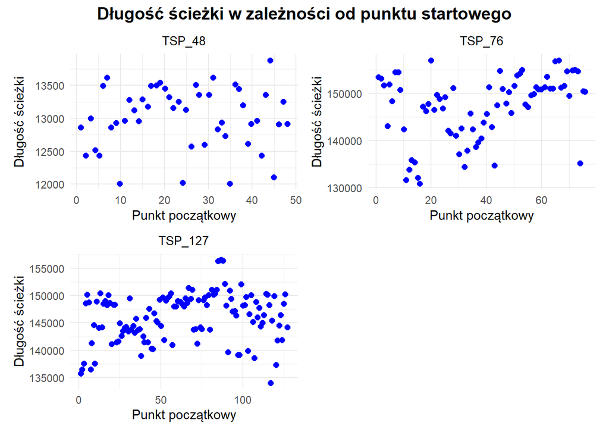

Na wykresach widzimy długość trasy w zależności od punktu startowego. Punkt startowy to miasto, z którego zaczynamy szukać najkrótszej trasy. Z wykresów nie da się wiele wyciągnąć, nie ma tutaj żadnej zależności. Widzimy jednak, że wybór punktu początkowego, z którego zaczyna algorytm ma znaczenie.

W tabelce widzimy najkrótsze ścieżki otrzymane dla poszczególnych TSP.

- **TSP_48**

| Punkt | Wynik | Ścieżka | CZAS |
| --- | --- | --- | --- |
| 10 | 12012 | [10, 24, 42, 5, 48, 39, 32, 21, 47, 11, 23, 14, 25, 13, 12, 15, 33, 46, 44, 18, 7, 28, 36, 30, 6, 37, 19, 27, 43, 17, 20, 40, 9, 1, 8, 38, 31, 22, 16, 3, 34, 41, 29, 2, 26, 4, 35, 45, 10] | 0.0000000000 |
| 35 | 12012 | [35, 45, 10, 24, 42, 5, 48, 39, 32, 21, 47, 11, 23, 14, 25, 13, 12, 15, 33, 46, 44, 18, 7, 28, 36, 30, 6, 37, 19, 27, 43, 17, 20, 40, 9, 1, 8, 38, 31, 22, 16, 3, 34, 41, 29, 2, 26, 4, 35] | 0.0003619194 |

Długość ścieżki wyniosła **12012** i jest to gorszy wynik od Solvera o **1144**. Średni wynik również jest gorszy. Ten wynik został uzyskany dla 2 punktów początkowych: 10 i 35.

- **TSP_76**

| Punkt | Wynik | Ścieżka | CZAS |
| --- | --- | --- | --- |
| 16 | 130921 | [16, 15, 13, 14, 12, 11, 17, 18, 37, 36, 35, 34, 40, 41, 60, 59, 58, 57, 63, 64, 62, 61, 55, 56, 51, 66, 65, 50, 49, 52, 53, 54, 42, 43, 28, 29, 30, 31, 19, 20, 5, 6, 7, 8, 9, 10, 4, 3, 2, 1, 23, 22, … | 0 |

Długość ścieżki wyniosła **130921** i jest to gorszy wynik od Solvera o **12627.5**. Średni wynik również jest gorszy. Wynik ten udało się uzyskać dla punktu początkowego 16.

- **TSP_127**

| Punkt | Wynik | Ścieżka | CZAS |
| --- | --- | --- | --- |
| 117 | 133970.6 | [117, 84, 81, 126, 82, 83, 75, 76, 78, 80, 79, 77, 18, 21, 17, 22, 4, 23, 24, 6, 106, 15, 108, 20, 19, 72, 8, 9, 11, 114, 105, 7, 1, 16, 2, 51, 57, 54, 45, 103, 44, 35, 36, 37, 41, 14, 12, 31, 27, 30,… | 0.002687454 |

Długość ścieżki wyniosła **133970.6** i jest to lepszy wynik od Solvera o **6247**. Średni wynik tutaj też jest gorszy. Wynik ten udało się uzyskać dla punktu początkowego 117.

Za pomocą tego algorytmu nie udało się uzyskać lepszych wyników niż Solver dla TSP_48 i TSP_76.

# Algorytm wspinaczki z multistartem (IHC)

**Algorytm iteracyjnej wspinaczki** to technika optymalizacyjna, stosowana do znajdowania zbliżonych do optymalnych rozwiązań problemów, które mogą mieć wiele lokalnych minimów. Wykorzystuje on podejście algorytmu wspinaczki, rozszerzone o wielokrotne losowanie różnych początkowych rozwiązań, co zwiększa szansę na znalezienie rozwiązania bliskiego globalnemu optimum.

Zasada działania algorytmu wspinaczki z multistartem do rozwiązania problemu komiwojażera:

1. Na początku każdej iteracji wybierane jest losowe rozwiązanie początkowe, które stanowi punkt wyjścia dla algorytmu wspinaczki górskiej.
2. Analizowane jest sąsiedztwo bieżącego rozwiązania w celu znalezienia trasy o najmniejszym koszcie, korzystając z wybranej metody sąsiedztwa.
3. Dla każdego sąsiedniego rozwiązania obliczany jest koszt trasy, który porównywany jest z aktualnym kosztem. Jeśli koszt sąsiedniej trasy jest niższy, zostaje ona zaakceptowana jako nowe rozwiązanie i proces powtarzany jest, aż nie będzie możliwe znalezienie lepszego rozwiązania.
4. Każda iteracja algorytmu jest ograniczona liczbą kroków (maksymalna liczba iteracji bez poprawy), a cały proces jest powtarzany przez określoną liczbę prób, aby uniknąć utknięcia w lokalnym optimum.
5. Dla każdej iteracji obliczany jest czas wykonania algorytmu, a najlepsze znalezione rozwiązanie jest zapisywane.
6. Algorytm kończy poszukiwania, gdy upłynie określony limit czasu lub po przeprowadzeniu zaplanowanej liczby iteracji.
7. Na koniec algorytm zwraca najlepszą znalezioną trasę.

## Badane parametry

W ramach algorytmu iteracyjnej wspinaczki badane są następujące parametry:

- **`num_starts`** - liczba iteracji
- **`neighborhood_type`** - rodzaj sąsiedztwa - metoda generowania nowych rozwiązań na podstawie aktualnego rozwiązania. W badaniu uwzględniono typy:
  - **`swap`** nowe rozwiązanie powstaje poprzez zamianę miejscami dwóch miast w bieżącej trasie
  - **`insertion`** polega na wyborze jednego miasta z danej trasy, usunięciu go z jego pierwotnej pozycji, a następnie wstawieniu go w inne, wybrane miejsce w tej samej trasie
  - **`two-opt`** wiąże się z odwróceniem segmentu trasy między dwoma wybranymi wierzchołkami, co prowadzi do zmiany kolejności miast w tym segmencie
- **`time_limit`** - limit czasowy, jaki posiada algorytm na znalezienie rozwiązania
- **`max_iterations_without_improvement`** - liczba iteracji bez poprawy - liczba iteracji, po której algorytm kończy działanie, jeśli nie znaleziono lepszego rozwiązania
- **`max_hill_climbing_iterations`** - liczba iteracji wspinaczki - liczba iteracji, jaką algorytm może wykonać w jednej próbie wspinaczki

### Klasyczne

Za podstawowe dane przyjmujemy:

- num_starts = 100,
- neighborhood_type = `two-opt`,
- time_limit = 500,
- max_iterations_without_improvement = 100,
- max_hill_climbing_iterations = 1000.

| TSP_48 | TSP_76 | TSP_127 |
| --- | --- | --- |
| 10779 | 110039.7 | 124989.8 |
| 10767 | 110389.6 | 124522.5 |
| 10766 | 110299.7 | 123747.9 |
| 10749 | 110457.4 | 124608.8 |
| 10791 | 110325.5 | 124226.2 |
| 10792 | 110371.1 | 123866.8 |
| 10713 | 110324.3 | 124969.5 |
| 10767 | 110090.5 | 122191.3 |
| 10773 | 110466.1 | 123912.2 |
| 10773 | 111101.1 | 124013.5 |

|  | Min | Max | Mean |
| --- | --- | --- | --- |
| TSP_48 | 10713.0 | 10792.0 | 10767.0 |
| TSP_76 | 110039.7 | 111101.1 | 110386.5 |
| TSP_127 | 122191.3 | 124989.8 | 124104.8 |

Powyżej w tabelkach możemy zobaczyć uzyskane wyniki dla algorytmu iteracyjnej wspinaczki oraz minimalną, maksymalną i średnią wartość. Uzyskane wyniki są bardzo dobre. Średnie w każdym z przypadku są o wiele niższe niż te uzyskane przez Solver.

**Czas**

|  | Min | Max | Mean |
| --- | --- | --- | --- |
| TSP_48 | 3.405578 | 6.816336 | 4.340777 |
| TSP_76 | 15.474391 | 28.707440 | 22.887653 |
| TSP_127 | 82.378339 | 153.110554 | 120.230649 |

Średnie czas są dość niskie dla TS_48 i TSP_76. Natomiast dla TSP_127 średni czas wynosi już ok. 2 minut.

### Liczba iteracji

Poniżej zbadany został wpływ liczby iteracji na długość ścieżki:

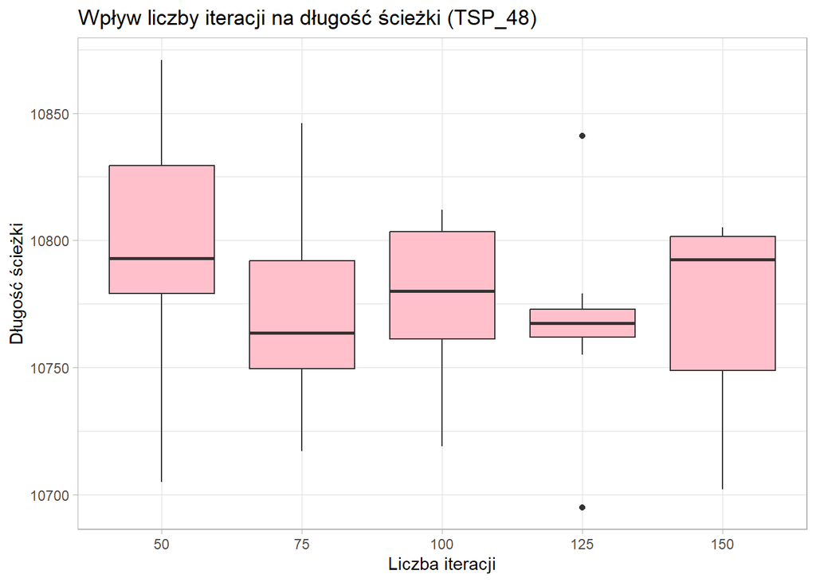

**Statystyki długości ścieżki w zależności od liczby iteracji (TSP_48)**

| PARAMETR | Min | Max | Mean |
| --- | --- | --- | --- |
| 50 | 10705 | 10871 | 10800.1 |
| 75 | 10717 | 10846 | 10773.4 |
| 100 | 10719 | 10812 | 10777.5 |
| 125 | 10695 | 10841 | 10767.7 |
| 150 | 10702 | 10805 | 10772.8 |

Mediana i średnie wahają się w zależności od liczby iteracji wokół podobnych wartości. Nie widać żadnej zależności.

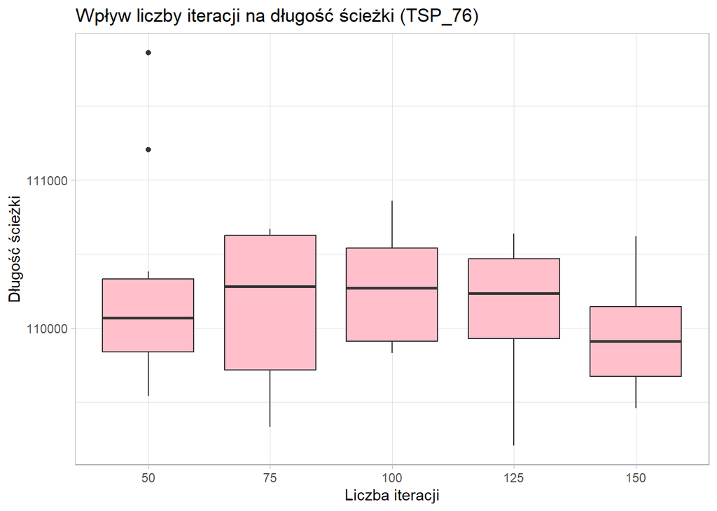

**Statystyki długości ścieżki w zależności od liczby iteracji (TSP_76)**

| PARAMETR | Min | Max | Mean |
| --- | --- | --- | --- |
| 50 | 109540.9 | 111859.1 | 110267.6 |
| 75 | 109331.5 | 110666.7 | 110150.3 |
| 100 | 109831.6 | 110860.0 | 110276.6 |
| 125 | 109207.4 | 110634.8 | 110104.9 |
| 150 | 109457.8 | 110616.4 | 109917.8 |

Tutaj analogiczna sytuacja. Średnie są natomiast bardzo niskie w porównaniu do Solvera.

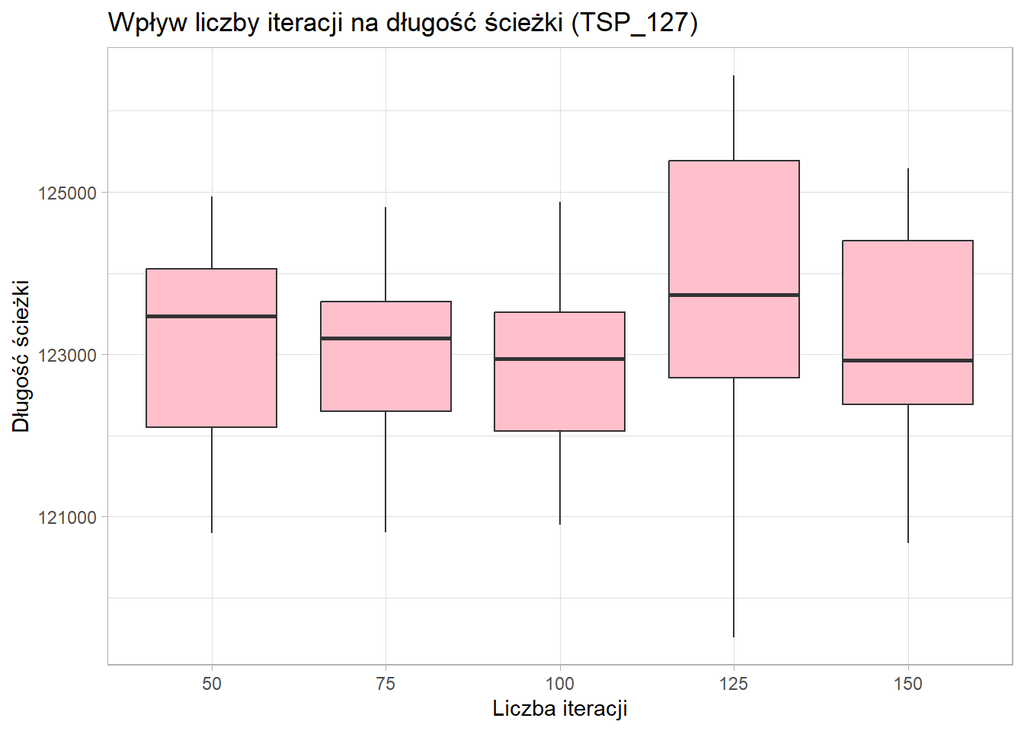

**Statystyki długości ścieżki w zależności od liczby iteracji (TSP_127)**

| PARAMETR | Min | Max | Mean |
| --- | --- | --- | --- |
| 50 | 120797.0 | 124940.8 | 123161.9 |
| 75 | 120802.3 | 124811.8 | 122873.6 |
| 100 | 120896.7 | 124876.7 | 122893.9 |
| 125 | 119515.0 | 126438.6 | 123577.4 |
| 150 | 120674.8 | 125288.3 | 123111.9 |

Dla TSP_127 pojawia się taka sama sytuacja.

W żadnym z przypadków nie widac, żadnej zależności. Jednak różnice w liczbie parametrów są dość małe. Możliwe, że sprawdzenie większej liczby iteracji pokazałoby jakąś zależność.

### Rodzaj sąsiedztwa

Poniżej zbadany został wpływ rodzaju sąsiedztwa na długość ścieżki:

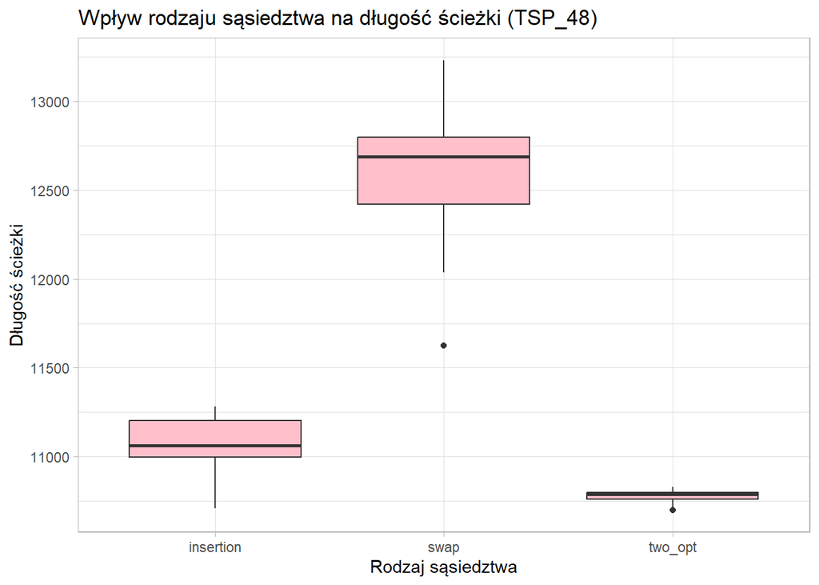

**Statystyki długości ścieżki w zależności od rodzaju sąsiedztwa (TSP_48)**

| PARAMETR | Min | Max | Mean |
| --- | --- | --- | --- |
| insertion | 10707 | 11281 | 11070.6 |
| swap | 11625 | 13232 | 12576.7 |
| two_opt | 10700 | 10830 | 10774.3 |

Rodzaj sąsiedztwa zdecydowanie wpływa na długości ścieżki. Mediana i średnia są najniższe w przypadku `two-opt`. Natomiast najgorsze wyniki są dla `swap`.

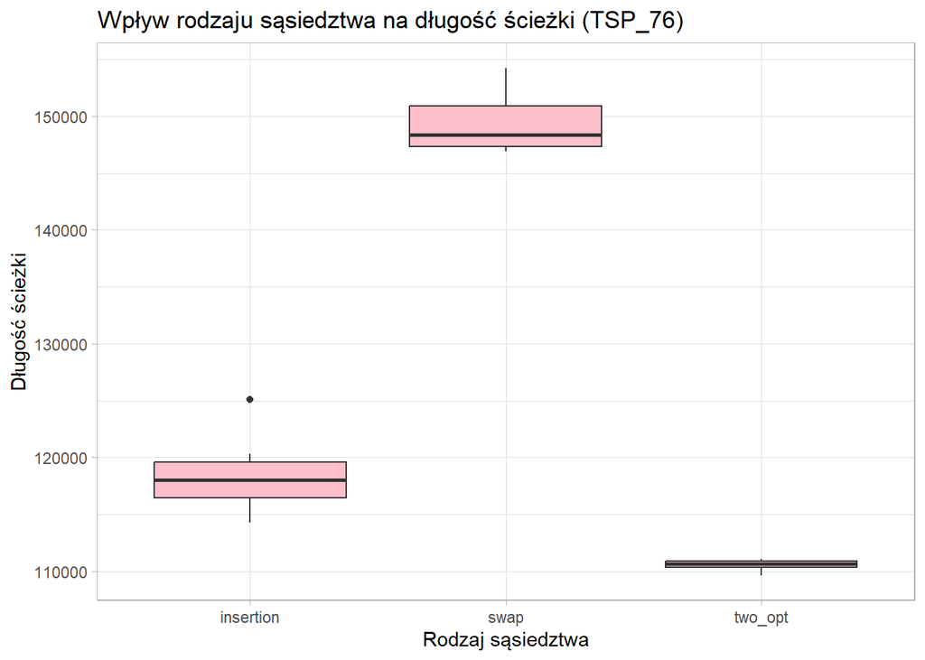

**Statystyki długości ścieżki w zależności od rodzaju sąsiedztwa (TSP_76)**

| PARAMETR | Min | Max | Mean |
| --- | --- | --- | --- |
| insertion | 114289.8 | 125121.8 | 118380.1 |
| swap | 146941.5 | 154251.4 | 149307.8 |
| two_opt | 109661.0 | 111110.3 | 110562.6 |

Tutaj jest bardzo podobna sytuacja. Dla `insetion` wyniki nie są najgorsze. Jednak jest dość znacząca różnica między nimi a `two-opt`.

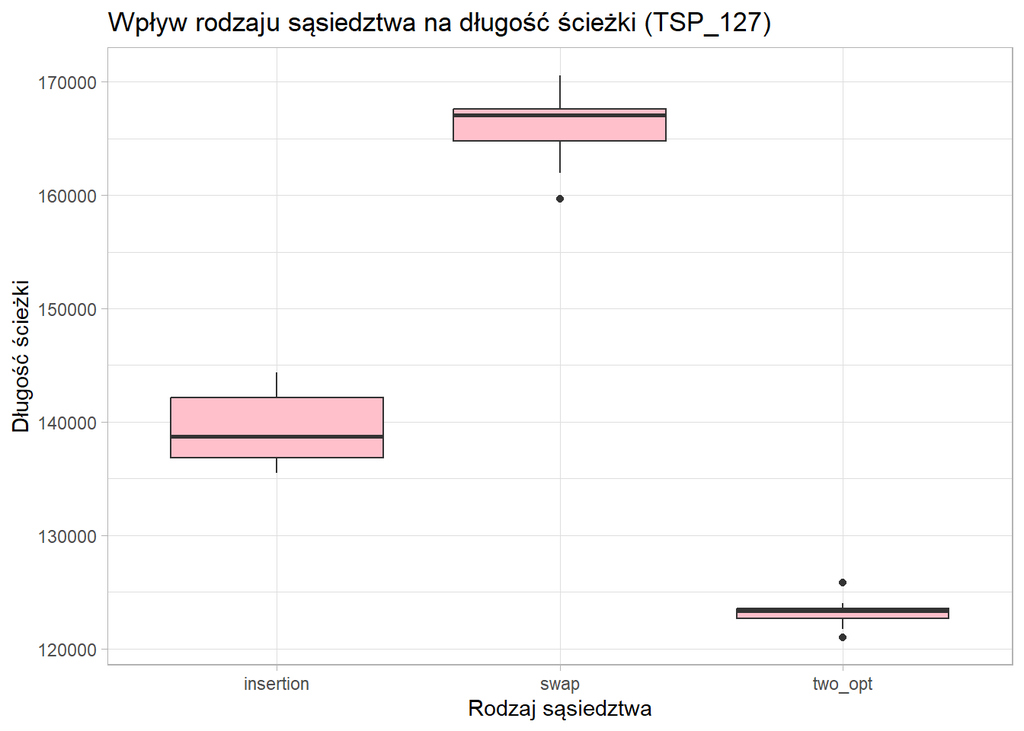

**Statystyki długości ścieżki w zależności od rodzaju sąsiedztwa (TSP_127)**

| PARAMETR | Min | Max | Mean |
| --- | --- | --- | --- |
| insertion | 135469.7 | 144355.5 | 139373.4 |
| swap | 159701.2 | 170572.6 | 166176.7 |
| two_opt | 121017.9 | 125837.1 | 123194.5 |

Dla TSP_127 jest identyczna sytuacja co w poprzednich TSP.

Długość ścieżki definitywnie zależy od rodzaju ruchu. Dla `two-opt` w każdym z przypadków wyniki są najlepsze. Natomiast dla `swap` najgorsza.

### Limit czasowy

Poniżej zbadany został wpływ limitu czasowego na długość ścieżki:

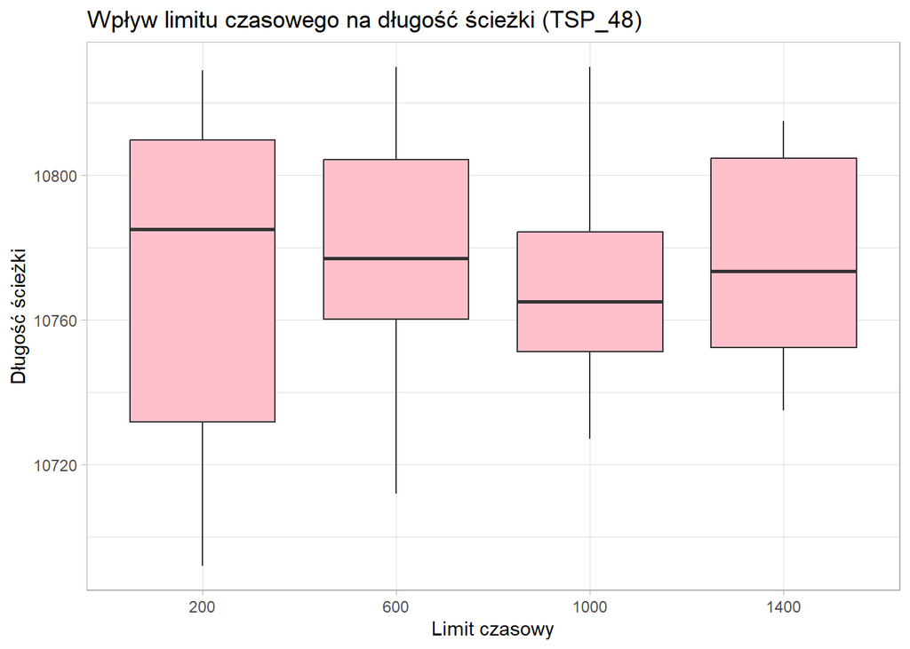

**Statystyki długości ścieżki w zależności od limitu czasowego (TSP_48)**

| PARAMETR | Min | Max | Mean |
| --- | --- | --- | --- |
| 200 | 10692 | 10829 | 10772.9 |
| 600 | 10712 | 10830 | 10775.6 |
| 1000 | 10727 | 10830 | 10769.4 |
| 1400 | 10735 | 10815 | 10776.2 |

Dla TSP_48 limit czasowy nie wydaje się wpływać na długość ścieżki. Średnie i mediany dla każdego parametru są dość zbliżone do siebie.

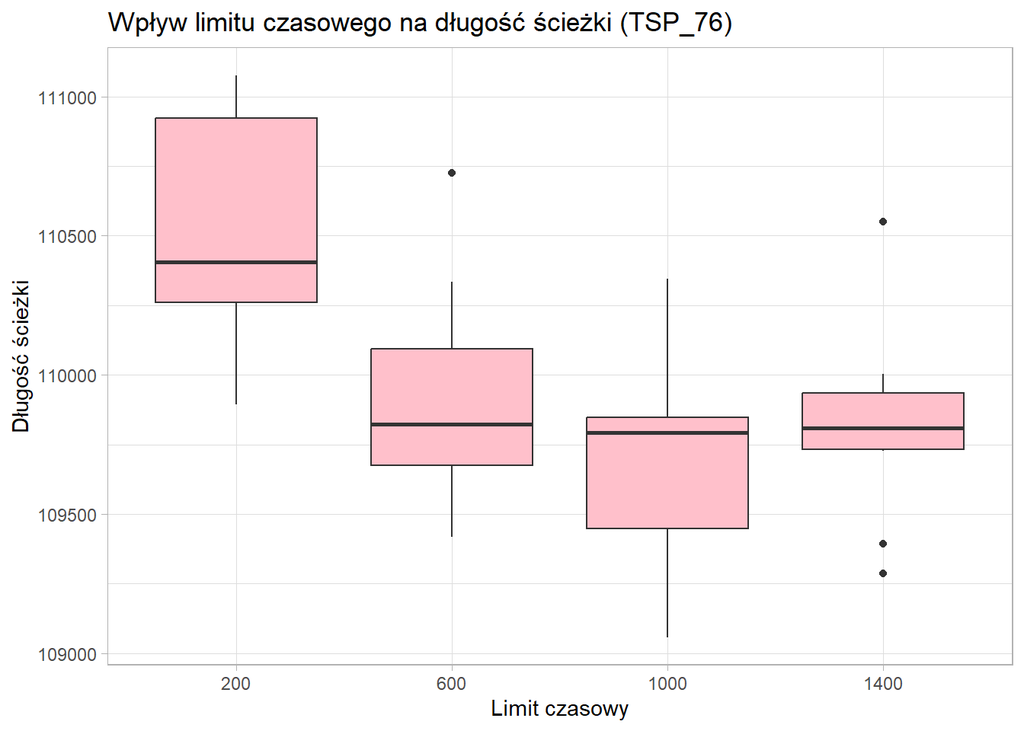

**Statystyki długości ścieżki w zależności od limitu czasowego (TSP_76)**

| PARAMETR | Min | Max | Mean |
| --- | --- | --- | --- |
| 200 | 109895.0 | 111076.4 | 110511.0 |
| 600 | 109418.9 | 110725.5 | 109916.9 |
| 1000 | 109058.3 | 110346.0 | 109693.2 |
| 1400 | 109287.7 | 110550.8 | 109816.0 |

Natomiast tutaj widzimy, że mediana i średnia długośći ścieżki maleją wraz ze wzrostem limitu czasowego. Jednak największy spadek jest na początku, później już te różnice są niewielkie.

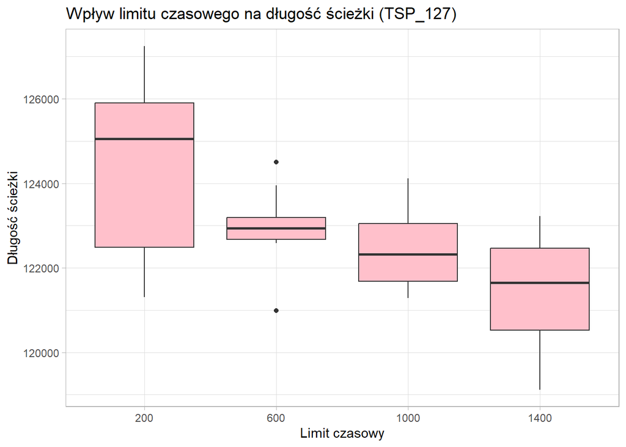

**Statystyki długości ścieżki w zależności od limitu czasowego (TSP_127)**

| PARAMETR | Min | Max | Mean |
| --- | --- | --- | --- |
| 200 | 121309.7 | 127249.3 | 124471.7 |
| 600 | 120986.9 | 124497.3 | 122967.7 |
| 1000 | 121281.8 | 124116.3 | 122432.8 |
| 1400 | 119118.3 | 123220.5 | 121499.2 |

Dla TSP_127 widać już jednak zdecydowanie malejącą średnią i mediane wraz ze wzrostem limitu czasowego.

### Liczba iteracji bez poprawy

Poniżej zbadany został wpływ liczby iteracji bez poprawy na długość ścieżki:

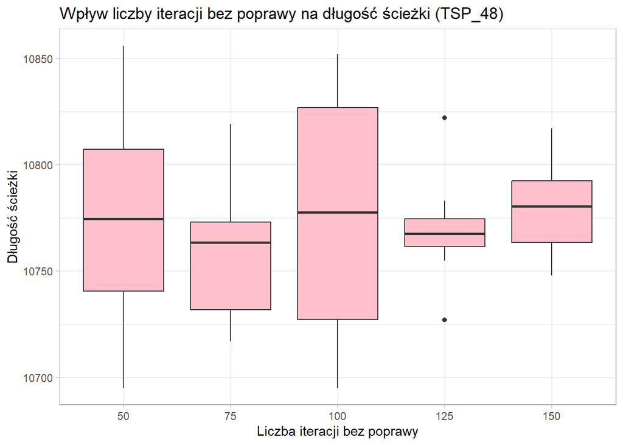

**Statystyki długości ścieżki w zależności od liczby iteracji bez poprawy (TSP_48)**

| PARAMETR | Min | Max | Mean |
| --- | --- | --- | --- |
| 50 | 10695 | 10856 | 10775.5 |
| 75 | 10717 | 10819 | 10759.9 |
| 100 | 10695 | 10852 | 10776.0 |
| 125 | 10727 | 10822 | 10769.4 |
| 150 | 10748 | 10817 | 10779.9 |

Mediana i średnia są dość zbliżone dla każdej wartości parametru. Nie widać tutaj znaczących różnic.

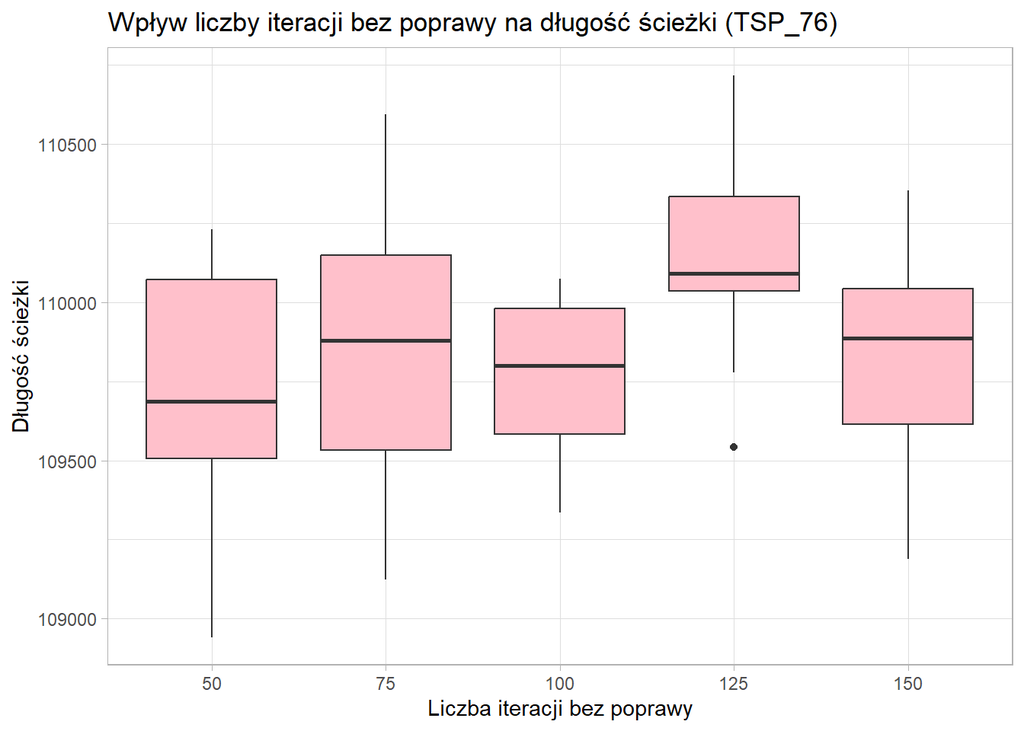

**Statystyki długości ścieżki w zależności od liczby iteracji bez poprawy (TSP_76)**

| PARAMETR | Min | Max | Mean |
| --- | --- | --- | --- |
| 50 | 108942.2 | 110229.8 | 109703.3 |
| 75 | 109123.7 | 110593.5 | 109868.1 |
| 100 | 109335.2 | 110073.7 | 109770.7 |
| 125 | 109543.1 | 110716.3 | 110136.2 |
| 150 | 109189.5 | 110353.5 | 109848.9 |

Dla TSP_76 pojawia się podobna sytuacja. W jednym z przypadków natomiast średnia i mediana są wyższe. Natomiast nie widać żadnej zależności.

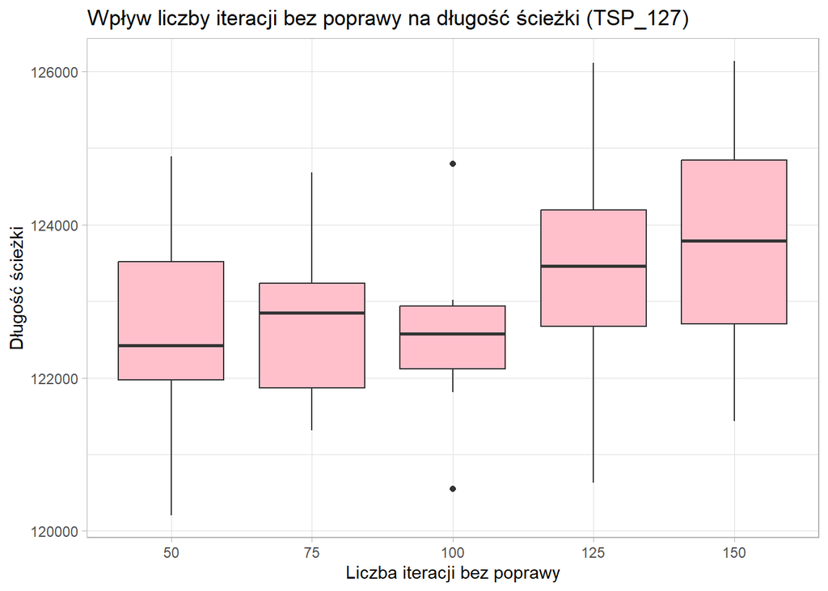

**Statystyki długości ścieżki w zależności od liczby iteracji bez poprawy (TSP_127)**

| PARAMETR | Min | Max | Mean |
| --- | --- | --- | --- |
| 50 | 120208.5 | 124887.9 | 122497.0 |
| 75 | 121316.6 | 124683.6 | 122696.2 |
| 100 | 120552.2 | 124793.9 | 122554.0 |
| 125 | 120634.2 | 126111.5 | 123477.2 |
| 150 | 121430.1 | 126137.5 | 123724.4 |

Tutaj natomiasst widzimy pod koniec wzrost mediany i średniej, który nie był widoczny wcześniej.

Nie widać tutaj, aby jakaś zależność się pojawiała. Ogólnie rzecz biorąc w każdym przypadku mediana i średnia zachowują się podobnie z pewnymi odstępstwami.

### Liczba iteracji wspinaczki

Poniżej zbadany został wpływ liczby iteracji wspinaczki na długość ścieżki:

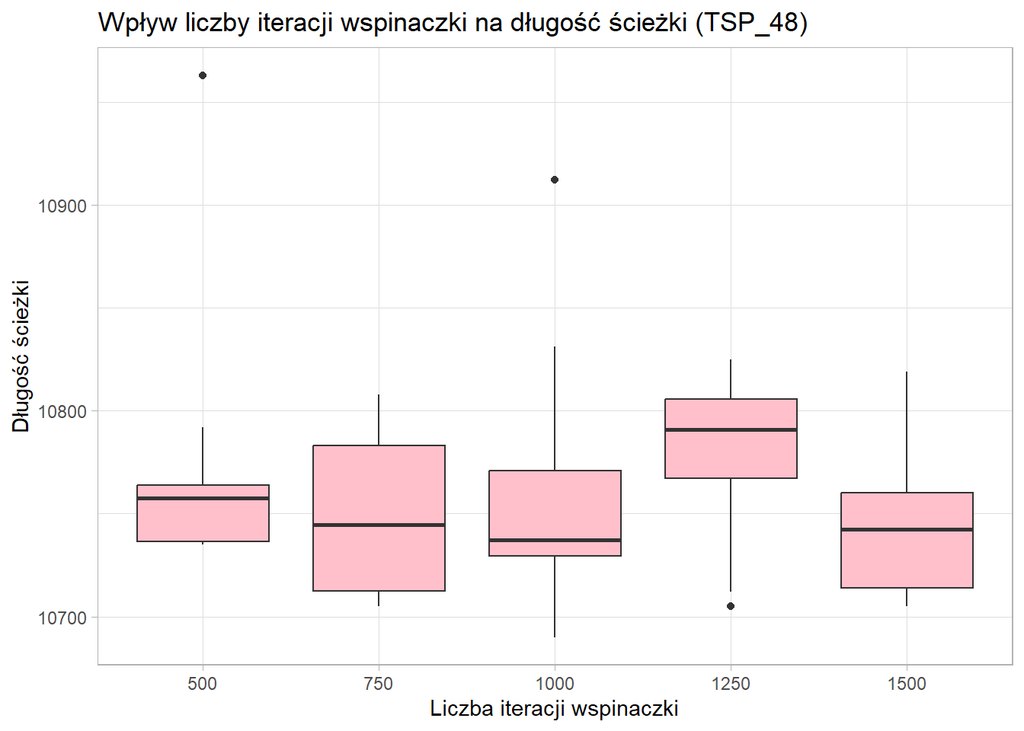

**Statystyki długości ścieżki w zależności od liczby iteracji wspinaczki (TSP_48)**

| PARAMETR | Min | Max | Mean |
| --- | --- | --- | --- |
| 500 | 10735 | 10963 | 10774.0 |
| 750 | 10705 | 10808 | 10749.4 |
| 1000 | 10690 | 10912 | 10759.4 |
| 1250 | 10705 | 10825 | 10778.2 |
| 1500 | 10705 | 10819 | 10746.8 |

Wyniki są dość zbliżone dla każdej wartości parametru. Średnia i mediana wahają się wokół podobnych wartośći.

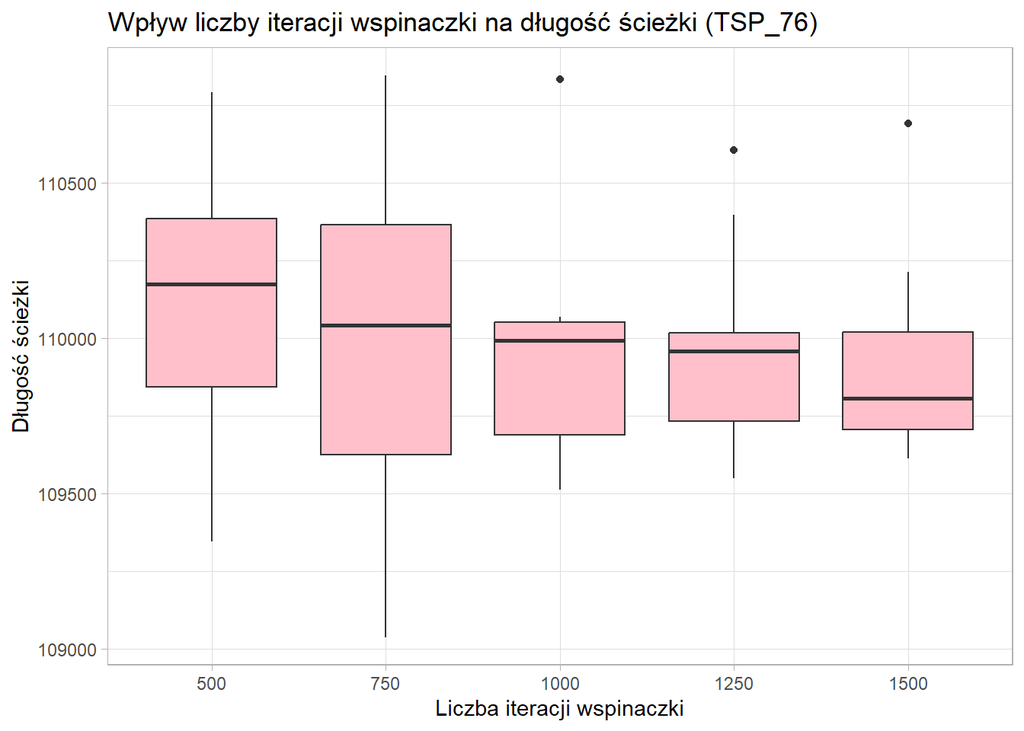

**Statystyki długości ścieżki w zależności od liczby iteracji wspinaczki (TSP_76)**

| PARAMETR | Min | Max | Mean |
| --- | --- | --- | --- |
| 500 | 109344.2 | 110792.0 | 110120.2 |
| 750 | 109036.8 | 110846.8 | 109980.4 |
| 1000 | 109511.2 | 110832.8 | 109946.2 |
| 1250 | 109548.0 | 110605.4 | 109952.2 |
| 1500 | 109611.9 | 110690.9 | 109914.8 |

Tutaj natomiast widzimy delikatny spadek mediany i średniej wraz ze wzrostem liczby iteracji wspinaczki. Jednak nie jest on bardzo znaczący.

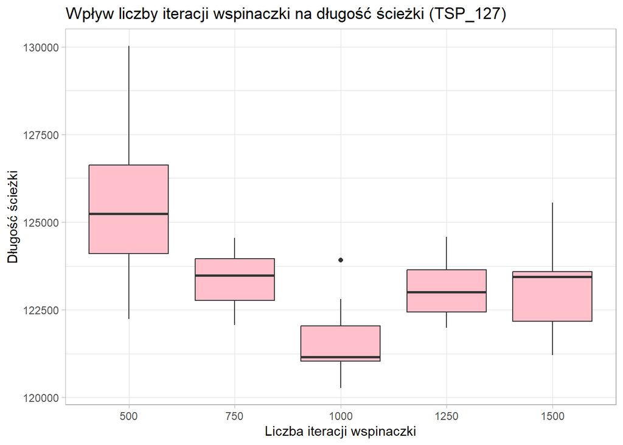

**Statystyki długości ścieżki w zależności od liczby iteracji wspinaczki (TSP_127)**

| PARAMETR | Min | Max | Mean |
| --- | --- | --- | --- |
| 500 | 122241.3 | 130026.4 | 125593.7 |
| 750 | 122063.2 | 124547.0 | 123394.5 |
| 1000 | 120273.5 | 123913.9 | 121585.5 |
| 1250 | 121988.4 | 124570.9 | 123089.6 |
| 1500 | 121208.8 | 125559.5 | 123062.6 |

Dla TSP_127 widać na początku dość intensywny spadek mediany i średniej, jednak później wartości wzrastają.

Ciężko stwierdzić czy isteniej tu jakaś zależność. Dla TSP_76 i TSP_127 widać na początku spadek mediany i średniej. Dla TSP_48 nie widać wpływu tego parametru.

## Podsumowanie

Najlepsze wyniki dla **TSP_48** przy zmianie poszczególnych parametrów:

- `Klasyczne` - 10713.0
- `Liczba iteracji` - 10695 (liczba iteracji - 125)
- `Rodzaj sąsiedztwa` - 10700 (rodzaj sąsiedztwa - two-opt)
- `Limit czasowy` - 10692 (limit czasowy - 200)
- `Liczba iteracji bez poprawy` - 10695 (liczba iteracji bez poprawy - 50)
- `Liczba iteracji wspinaczki` - 10690 (liczba iteracji wspinaczki - 1000)

Dla TSP_48 przy użyciu algorytmu iteracyjnej wspinaczki z multistartem udało się uzyskać zdecydownie lepsze wyniki niż ten uzyskany przez Solver (10868).

Najlepsze wyniki dla **TSP_76** przy zmianie poszczególnych parametrów:

- `Klasyczne` - 110039.7
- `Liczba iteracji` - 109207.4 (liczba iteracji - 125)
- `Rodzaj sąsiedztwa` - 109661.0 (rodzaj sąsiedztwa - two-opt)
- `Limit czasowy` - 109058.3 (limit czasowy - 1000)
- `Liczba iteracji bez poprawy` - 108942.2 (liczba iteracji bez poprawy - 50)
- `Liczba iteracji wspinaczki` - 109036.8 (liczba iteracji wspinaczki - 750)

Dla TSP_76 przy użyciu algorytmu iteracyjnej wspinaczki z multistartem również udało się uzyskać zdecydowanie lepsze wyniki niż ten uzyskany przez Solver (118293.5).

Najlepsze wyniki dla **TSP_127** przy zmianie poszczególnych parametrów:

- `Klasyczne` - 122191.3
- `Liczba iteracji` - 119515.0 (liczba iteracji - 125)
- `Rodzaj sąsiedztwa` - 121017.9 (rodzaj sąsiedztwa - two-opt)
- `Limit czasowy` - 119118.3 (limit czasowy - 1400)
- `Liczba iteracji bez poprawy` - 120208.5 (liczba iteracji bez poprawy - 50)
- `Liczba iteracji wspinaczki` - 120273.5 (liczba iteracji wspinaczki - 1000)

Dla TSP_127 przy użyciu algorytmu iteracyjnej wspinaczki z multistartem również są lepsze wyniki niż ten uzyskany przez Solver (140217.6).

# Algorytm symulowanego wyżarzania (SA)

**Algorytm symulowanego wyżarzania** (ang. Simulated Annealing, SA) jest iteracyjną metodą optymalizacji, która rozpoczyna się od losowego rozwiązania i w każdej iteracji wprowadza zmiany w obrębie sąsiedztwa. Inspiracją dla algorytmu SA był proces metalurgiczny, w którym metal w wysokich temperaturach łatwiej poddaje się obróbce plastycznej. W miarę obniżania temperatury, zmiany kształtu stają się coraz trudniejsze. Podobnie, w algorytmie symulowanego wyżarzania na początku akceptowane są ruchy prowadzące do gorszych rozwiązań z relatywnie dużym prawdopodobieństwem, gdy temperatura jest wysoka. Z upływem iteracji oraz spadkiem temperatury, prawdopodobieństwo akceptacji gorszych rozwiązań maleje, co skutkuje tym, że algorytm niemal zawsze odrzuca pogarszające ruchy. Mechanizm ten ma na celu unikanie utknięcia w ekstremach lokalnych. W każdej iteracji generowane są losowe ruchy, a ich liczba jest parametryzowana w danej implementacji.

Zasada działania algorytmu symulowanego wyżarzania do rozwiązania problemu komiwojażera:

1. Na początku losowo generowana jest początkowa trasa, która reprezentuje kolejność odwiedzania miast. Ta trasa jest traktowana jako bieżące rozwiązanie i wyznaczany jest koszt tej trasy.
2. Ustalana jest początkowa wartość temperatury, która kontroluje prawdopodobieństwo akceptacji gorszych rozwiązań w trakcie przeszukiwania.
3. W każdej iteracji generowany jest sąsiad bieżącego rozwiązania w oparciu o wybrany typ ruchu.
4. Dla nowego rozwiązania obliczany jest koszt, a następnie różnica kosztów między bieżącym a sąsiednim rozwiązaniem.
5. Jeśli nowa trasa jest lepsza, algorytm akceptuje ją jako nowe bieżące rozwiązanie. Jeśli jest gorsza, algorytm może ją zaakceptować z prawdopodobieństwem zależnym od różnicy kosztów i aktualnej temperatury.
6. Jeśli bieżące rozwiązanie jest lepsze od dotychczasowego najlepszego rozwiązania, algorytm zapisuje je jako nowe najlepsze rozwiązanie.
7. Po każdej iteracji temperatura jest zmniejszana poprzez pomnożenie jej przez współczynnik chłodzenia. Obniżanie temperatury zmniejsza prawdopodobieństwo akceptacji gorszych rozwiązań.
8. Algorytm kończy działanie, gdy spełniony zostanie jeden z warunków zakończenia: liczba iteracji osiągnie maksymalną wartość, temperatura spadnie poniżej minimalnej wartości, lub czas działania przekroczy ustalony limit.
9. Po zakończeniu działania algorytm zwraca najlepsze znalezione rozwiązanie.

## Badane parametry

W ramach algorytmu symulowanego wyżarzania badane są następujące parametry:

- **`move_type`** - rodzaj sąsiedztwa - metoda generowania nowych rozwiązań na podstawie aktualnego rozwiązania. W badaniu uwzględniono typy:
  - `swap` nowe rozwiązanie powstaje poprzez zamianę miejscami dwóch miast w bieżącej trasie
  - `insertion` polega na wyborze jednego miasta z danej trasy, usunięciu go z jego pierwotnej pozycji, a następnie wstawieniu go w inne, wybrane miejsce w tej samej trasie
  - `two-opt` wiąże się z odwróceniem segmentu trasy między dwoma wybranymi wierzchołkami, co prowadzi do zmiany kolejności miast w tym segmencie
- **`initial_temperature`** - początkowa wartość temperatury, która kontroluje akceptację gorszych rozwiązań.
- **`cooling_rate`** - współczynnik chłodzenia, określający szybkość obniżania temperatury w kolejnych iteracjach
- **`max_iterations`** - liczba iteracji, po których algorytm kończy działanie
- **`min_temperature`** -minimalna wartość temperatury, poniżej której algorytm kończy działanie
- **`time_limit`** - limit czasowy

### Klasyczne

Za podstawowe dane przyjmujemy :

- initial_temperature = 10000
- cooling_rate = 0.99
- max_iterations = 10000
- min_temperature = 1e-100
- time_limit = `None`
- move_type = `two_opt`

| TSP_48 | TSP_76 | TSP_127 |
| --- | --- | --- |
| 11111 | 121505.1 | 154568.2 |
| 11526 | 119634.6 | 147496.4 |
| 11236 | 116708.4 | 164032.3 |
| 11100 | 120502.1 | 151760.1 |
| 11289 | 117467.4 | 166835.2 |
| 11757 | 123332.5 | 155187.5 |
| 11176 | 119815.0 | 155378.7 |
| 11588 | 121256.1 | 152658.4 |
| 11190 | 119213.6 | 156341.1 |
| 11263 | 122659.5 | 154994.8 |

|  | Min | Max | Mean |
| --- | --- | --- | --- |
| TSP_48 | 11100.0 | 11757.0 | 11323.6 |
| TSP_76 | 116708.4 | 123332.5 | 120209.4 |
| TSP_127 | 147496.4 | 166835.2 | 155925.3 |

Powyżej w tabelkach możemy zobaczyć uzyskane wyniki dla algorytmu symulowanego wyżarzania oraz minimalną, maksymalną i średnią wartość. Dla TSP_48 wyniki są zbliżone do tych z Solvera. Dla TSP_127 minimalna wartość jest trochę wyższa. Natomiast dla TSP_76 minimalna wartość jest zdecydowanie lepsza, jak również średnia.

|  | Min | Max | Mean |
| --- | --- | --- | --- |
| TSP_48 | 0.2058094 | 0.2837675 | 0.2280922 |
| TSP_76 | 0.3165832 | 0.3336225 | 0.3267073 |
| TSP_127 | 0.4666691 | 0.5335572 | 0.4951642 |

Uzyskane czasy przy podstawowych parametrach są bardzo niskie, nie wynoszą nawet sekundy. W Solverze w każdym z przypadków były one zdecydowanie wyższe.

### Rodzaj sąsiedztwa

Poniżej zbadany został wpływ rodzaju sąsiedztwa na długość ścieżki:

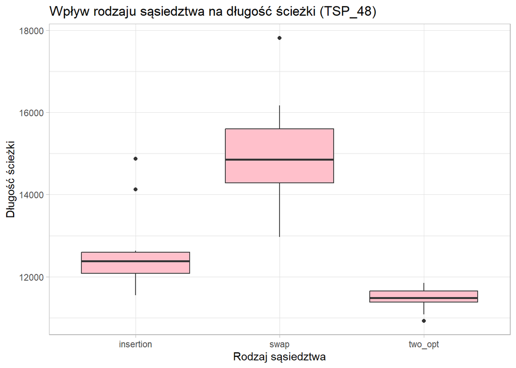

**Statystyki długości ścieżki w zależności od rodzaju sąsiedztwa (TSP_48)**

| PARAMETR | Min | Max | Mean |
| --- | --- | --- | --- |
| insertion | 11545 | 14875 | 12657.9 |
| swap | 12966 | 17815 | 15023.7 |
| two_opt | 10928 | 11846 | 11463.7 |

Widzimy, że sposób w jaki generujemy sąsiadów w algorytmie ma tutaj duże znaczenie. Wyniki są najgorsze w przypadku `swap` - średnia jest wysoka. Natomiast mediana i średnia długości ścieżki są najniższe w przypadku ruchu `2-opt`. Wyniki dla `2-opt` charakteryzują się małą wariancją (rozkład jest wąski), co wskazuje na niewielkie różnice w długościach ścieżek.

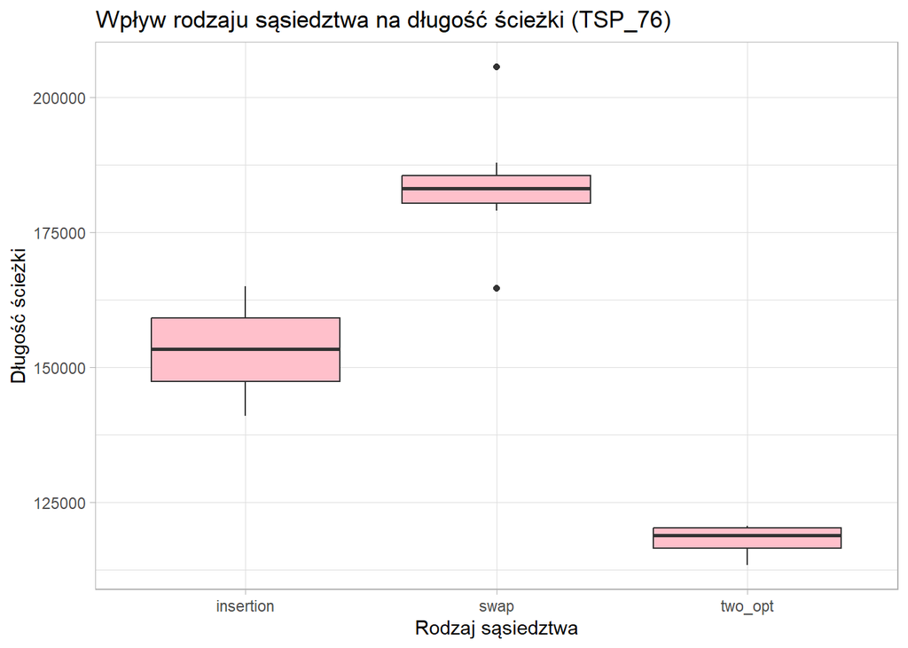

**Statystyki długości ścieżki w zależności od rodzaju sąsiedztwa (TSP_76)**

| PARAMETR | Min | Max | Mean |
| --- | --- | --- | --- |
| insertion | 141013.7 | 165010.7 | 153316.7 |
| swap | 164588.8 | 205608.9 | 183505.3 |
| two_opt | 113460.2 | 120653.1 | 118289.5 |

Dla TSP_76 pojawiła się analogiczna sytuacja. Dla `2-opt` wyniki są najlepsze. Uzyskana minimalna długość ścieżki dla tej wartości parametru jest znacząco lepsza od Solvera (118293.5). Ponownie najgorzej wypada `swap`. Średnie różnią się znacząco w zależności od typu ruchu.

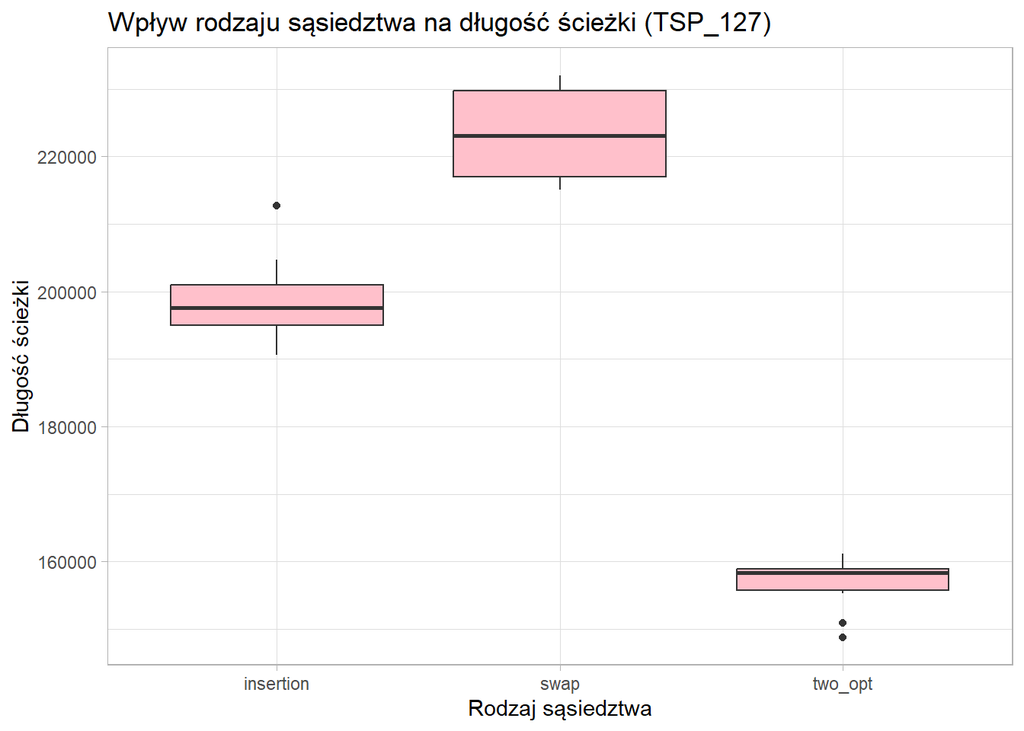

**Statystyki długości ścieżki w zależności od rodzaju sąsiedztwa (TSP_127)**

| PARAMETR | Min | Max | Mean |
| --- | --- | --- | --- |
| insertion | 190626.0 | 212672.6 | 198842.5 |
| swap | 215018.3 | 232022.1 | 223260.3 |
| two_opt | 148832.8 | 161190.9 | 156875.0 |

Tutaj sytuacja analogiczna. Wyniki są słabe dla `insertion` i `swap`. Natomiast dla `2-opt` już nie ma lepszych wyników niż w przypadku Solvera.

Jest tu dobrze widoczna zależność, że najkrótsza średnia i mediana długości ścieżki są w przypadku typu ruchu `2-opt`. Dla tej wartości parametru wariancja jest również w każdym z przypadków najmniejsza. Parametry `swap` i `insertion` nie działają tak efektywnie jak `2-opt`.

### Temperatura początkowa

Poniżej zbadany został wpływ temperatury początkowej na długość ścieżki:

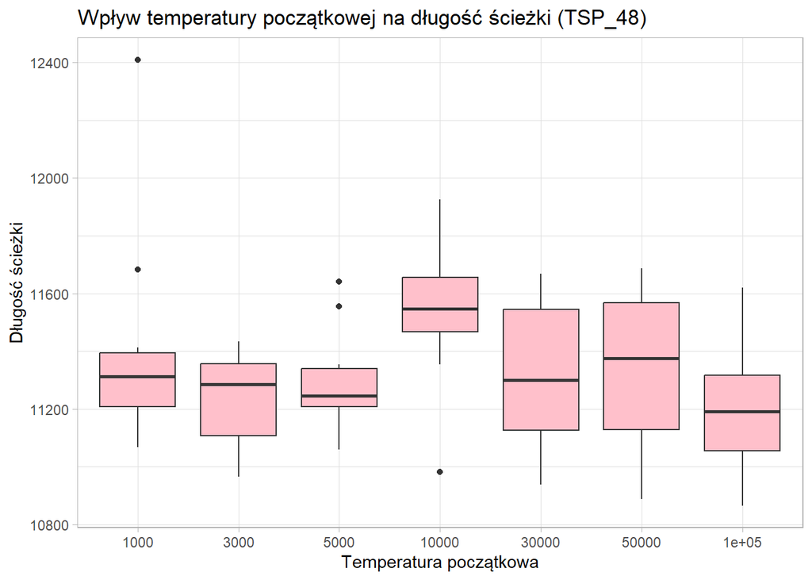

**Statystyki długości ścieżki w zależności od wartości temperatury początkowej (TSP_48)**

| PARAMETR | Min | Max | Mean |
| --- | --- | --- | --- |
| 1e+03 | 11068 | 12409 | 11412.2 |
| 3e+03 | 10965 | 11433 | 11238.9 |
| 5e+03 | 11059 | 11640 | 11295.1 |
| 1e+04 | 10982 | 11925 | 11539.6 |
| 3e+04 | 10938 | 11669 | 11313.2 |
| 5e+04 | 10887 | 11686 | 11343.9 |
| 1e+05 | 10866 | 11619 | 11221.9 |

Z wykresów pudełkowych nie widać żadnej zależności. Mediana i średnia długości ścieżki wahają się na podobnym poziomie dla różnych wartości parametru. Temperatura początkowa wydaję się nie mieć dużego wpływu.

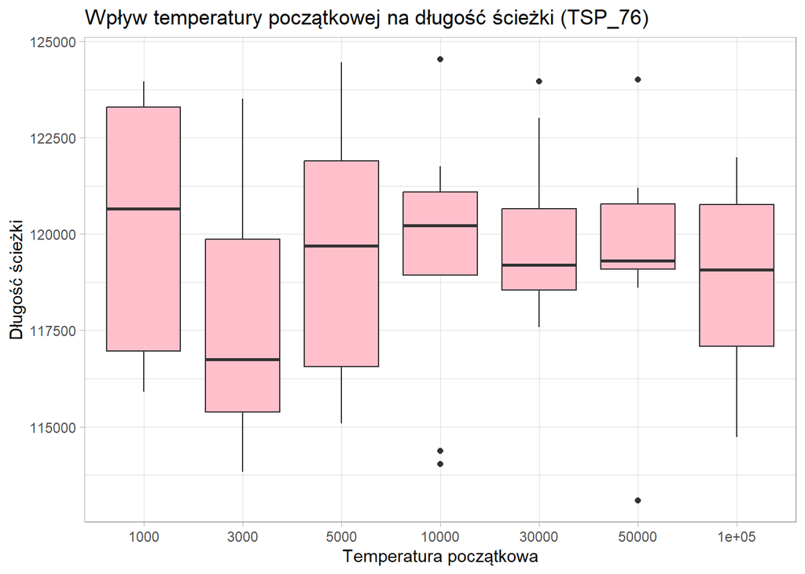

**Statystyki długości ścieżki w zależności od wartości temperatury początkowej (TSP_76)**

| PARAMETR | Min | Max | Mean |
| --- | --- | --- | --- |
| 1e+03 | 115914.3 | 123960.3 | 120149.4 |
| 3e+03 | 113827.4 | 123504.0 | 117664.9 |
| 5e+03 | 115088.7 | 124458.4 | 119515.6 |
| 1e+04 | 114034.3 | 124539.5 | 119525.9 |
| 3e+04 | 117579.4 | 123956.0 | 119898.9 |
| 5e+04 | 113094.6 | 124001.7 | 119501.1 |
| 1e+05 | 114733.2 | 121990.7 | 118851.5 |

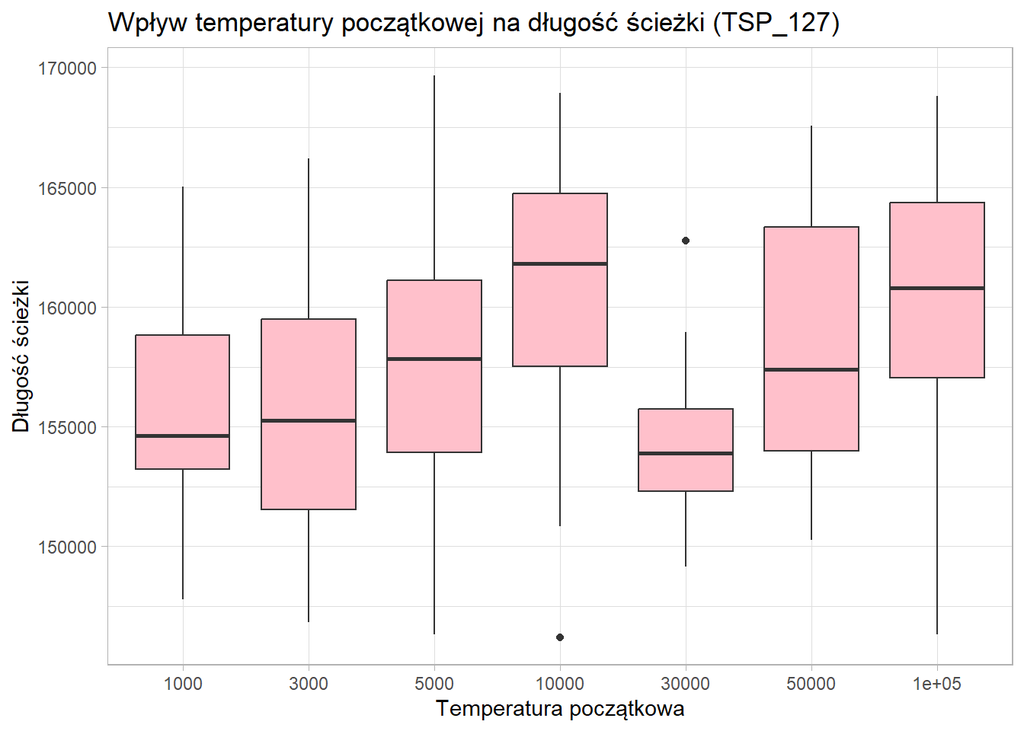

**Statystyki długości ścieżki w zależności od wartości temperatury początkowej (TSP_127)**

| PARAMETR | Min | Max | Mean |
| --- | --- | --- | --- |
| 1e+03 | 147796.5 | 165029.1 | 155618.5 |
| 3e+03 | 146825.9 | 166200.3 | 155867.7 |
| 5e+03 | 146337.6 | 169674.5 | 157509.3 |
| 1e+04 | 146215.7 | 168916.5 | 159915.9 |
| 3e+04 | 149142.2 | 162774.5 | 154478.4 |
| 5e+04 | 150258.9 | 167558.7 | 158831.6 |
| 1e+05 | 146322.8 | 168789.7 | 159298.2 |

Dla TSP_127 mediana i średnia długości ścieżki rosną. Następnie pojawia się spadek i ponownie wzrost. Nie można jednak powiedzieć, że tak będzie za każdym razem. Należałoby sprawdzić większą liczbę parametrów. Wyniki jednak dalej są dość słabe.

Wpływ początkowej temperatury nie wydaje się być duży.

### Prędkość chłodzenia

Poniżej zbadany został wpływ prędkości chłodzenia na długość ścieżki:

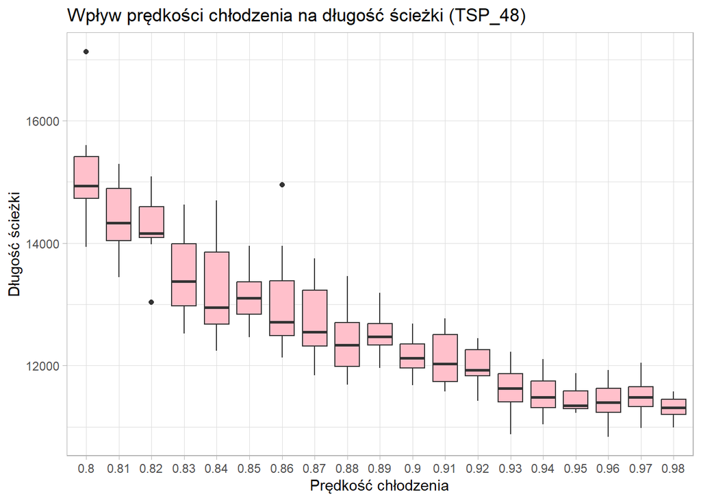

**Statystyki długości ścieżki w zależności od prędkości chłodzenia (TSP_48)**

| PARAMETR | Min | Max | Mean |
| --- | --- | --- | --- |
| 0.80 | 13939 | 17130 | 15095.9 |
| 0.81 | 13447 | 15292 | 14367.2 |
| 0.82 | 13035 | 15091 | 14262.5 |
| 0.83 | 12521 | 14627 | 13494.5 |
| 0.84 | 12242 | 14695 | 13293.2 |
| 0.85 | 12459 | 13951 | 13113.4 |
| 0.86 | 12129 | 14953 | 13064.2 |
| 0.87 | 11839 | 13754 | 12725.8 |
| 0.88 | 11690 | 13462 | 12365.6 |
| 0.89 | 11961 | 13185 | 12491.0 |

[output cut: 9 more lines]

Z wykresu bardzo dobrze widać jak mediana długości ścieżki maleje wraz ze wzrostem prędkości chłodzenia. Średnia również wykazuje takie zachowanie. Jednak pod koniec mediana i średnia długości ścieżki nie maleją tak szybko, stają się wręcz zbliżone (0.94-0.98).

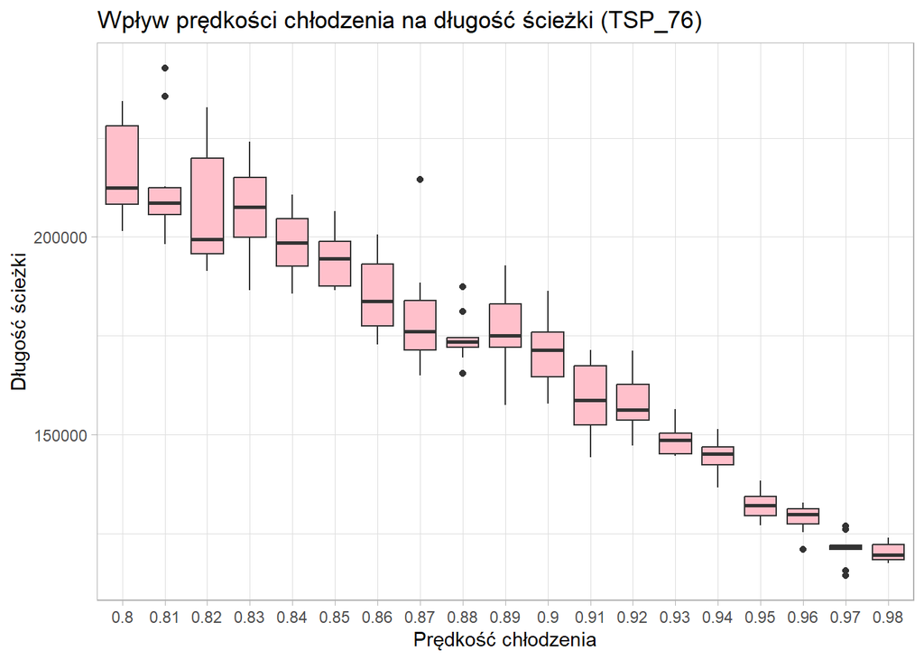

**Statystyki długości ścieżki w zależności od prędkości chłodzenia (TSP_76)**

| PARAMETR | Min | Max | Mean |
| --- | --- | --- | --- |
| 0.80 | 201412.6 | 234310.7 | 216615.0 |
| 0.81 | 198084.2 | 242763.3 | 213099.7 |
| 0.82 | 191382.3 | 232792.7 | 206663.2 |
| 0.83 | 186449.0 | 224118.4 | 206948.4 |
| 0.84 | 185710.5 | 210647.0 | 198075.5 |
| 0.85 | 186472.1 | 206463.3 | 194693.1 |
| 0.86 | 172841.3 | 200651.7 | 185705.0 |
| 0.87 | 165024.2 | 214459.8 | 179272.8 |
| 0.88 | 165488.4 | 187357.2 | 174276.5 |
| 0.89 | 157505.5 | 192776.9 | 176389.2 |

[output cut: 9 more lines]

Dla TSP_76 pojawiła się analogiczna sytuacja. Wraz ze wzrostem prędkości chłodzenia maleje mediana i średnia długości ścieżki.

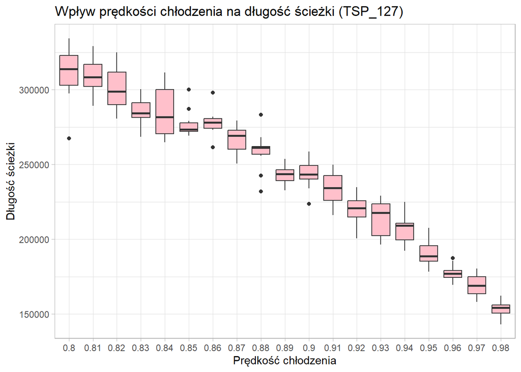

**Statystyki długości ścieżki w zależności od prędkości chłodzenia (TSP_127)**

| PARAMETR | Min | Max | Mean |
| --- | --- | --- | --- |
| 0.80 | 267515.2 | 334370.8 | 310325.0 |
| 0.81 | 289280.0 | 329199.7 | 309224.1 |
| 0.82 | 280655.8 | 325010.3 | 300974.4 |
| 0.83 | 268389.0 | 300294.7 | 285956.1 |
| 0.84 | 264898.2 | 311425.3 | 285274.2 |
| 0.85 | 269106.6 | 300022.2 | 277120.3 |
| 0.86 | 261468.1 | 297883.0 | 278023.0 |
| 0.87 | 250493.4 | 279437.6 | 266515.6 |
| 0.88 | 231951.2 | 283142.0 | 258825.3 |
| 0.89 | 232621.9 | 253726.5 | 243118.9 |

[output cut: 9 more lines]

W tym przypadku sytuacja jest identyczna.

### Liczba iteracji

Poniżej zbadany został wpływ liczby iteracji na długość ścieżki:

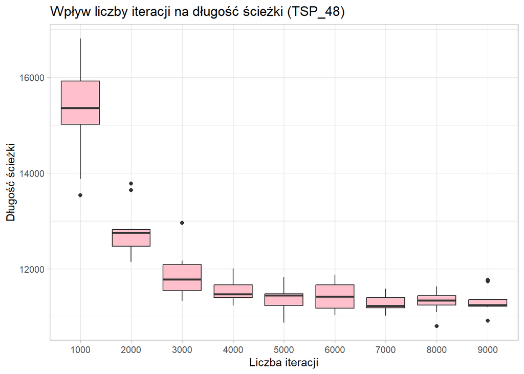

**Statystyki długości ścieżki w zależności od liczby iteracji (TSP_48)**

| PARAMETR | Min | Max | Mean |
| --- | --- | --- | --- |
| 1000 | 13541 | 16811 | 15297.2 |
| 2000 | 12146 | 13785 | 12783.1 |
| 3000 | 11336 | 12964 | 11864.7 |
| 4000 | 11236 | 12014 | 11534.3 |
| 5000 | 10879 | 11829 | 11395.6 |
| 6000 | 11038 | 11882 | 11452.4 |
| 7000 | 11023 | 11591 | 11285.4 |
| 8000 | 10811 | 11640 | 11317.2 |
| 9000 | 10923 | 11776 | 11330.3 |

DLa TSP_48 z wykresów dobrze widać, że wraz ze wzrostem liczby iteracji, maleje mediana i średnia długości ścieżki. Na początku maleją dość szybko, natomiast później następuje spowolnienie. Dla bardzo wysokich wartości parametrów nie widać już znaczących różnic w wynikach.

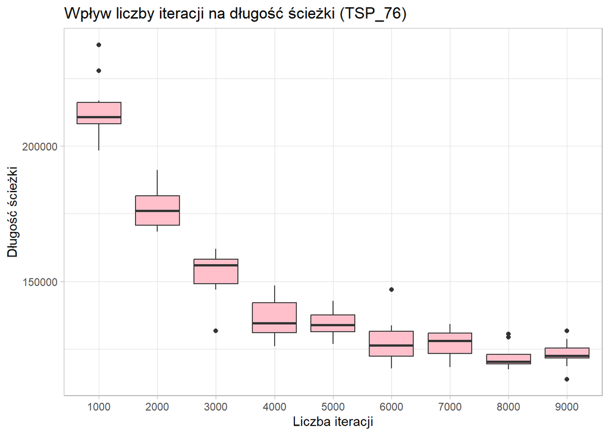

**Statystyki długości ścieżki w zależności od liczby iteracji (TSP_76)**

| PARAMETR | Min | Max | Mean |
| --- | --- | --- | --- |
| 1000 | 198313.6 | 237502.8 | 213134.3 |
| 2000 | 168419.5 | 191195.2 | 176865.0 |
| 3000 | 131722.0 | 162034.8 | 152931.7 |
| 4000 | 126003.7 | 148465.4 | 135987.9 |
| 5000 | 126724.1 | 142682.1 | 134715.1 |
| 6000 | 117815.2 | 146842.2 | 128042.3 |
| 7000 | 118285.9 | 134257.0 | 127001.1 |
| 8000 | 117458.2 | 130437.7 | 122071.7 |
| 9000 | 113809.8 | 131631.5 | 123083.3 |

Tutaj pojawia się podobna sytuacja. Jednak w tym przypadku mediana i średnia dłużej maleją. Dopiero dla liczby iteracji = 6000 (dla TSP_48 = 4000), wartości statystyk stają sie do siebie zbliżone.

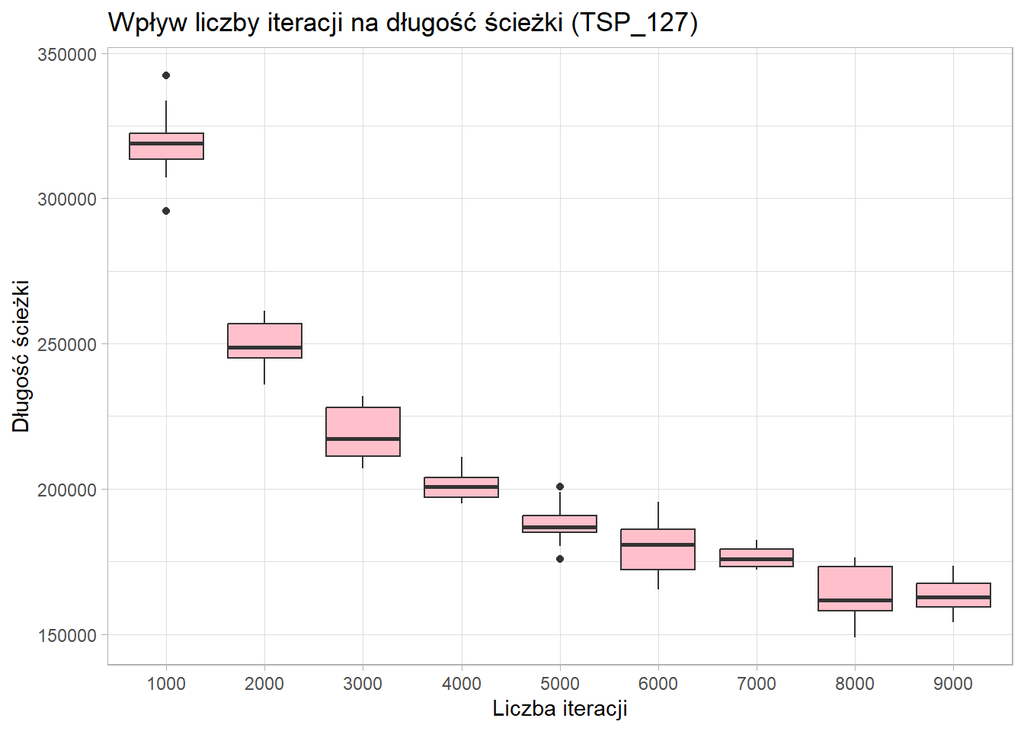

**Statystyki długości ścieżki w zależności od liczby iteracji (TSP_127)**

| PARAMETR | Min | Max | Mean |
| --- | --- | --- | --- |
| 1000 | 295711.7 | 342425.9 | 318856.5 |
| 2000 | 235785.6 | 261325.8 | 249865.2 |
| 3000 | 207017.7 | 231906.0 | 219391.8 |
| 4000 | 194982.5 | 211071.6 | 201197.1 |
| 5000 | 175953.9 | 200767.3 | 188217.5 |
| 6000 | 165347.6 | 195558.3 | 179791.4 |
| 7000 | 172093.1 | 182319.8 | 176491.6 |
| 8000 | 148956.7 | 176271.9 | 164123.8 |
| 9000 | 154106.9 | 173580.3 | 163153.5 |

Analogicznie dla TSP_127. Wraz ze wzrostem liczby iteracji, maleje średnia i mediana długości ścieżki. Jednak robi to jeszcze wolniej niż w poprzednich przypadkach. Dopiero dla liczby iteracji = 8000 statysyki się wahają wokół podobnych wartości.

We wszystkich sytuacjach widać, że wraz ze wzrostem liczby iteracji, maleje mediana i średnia długości ścieżki. Jednakże w pewnym momencie, różnym w zależności od liczby miast w problemie, osiągane wyniki przestają się znacząco różnić. Oznacza to, że algorytm stabilizuje się i zaczyna zbliżać się do swojego optimum. Dalsze zwiększanie liczby iteracji prowadzi jedynie do minimalnych zmian w wynikach, więc nie ma większego sensu.

### Minimalna temperatura

Poniżej zbadany został wpływ minimalnej temperatury na długość ścieżki:

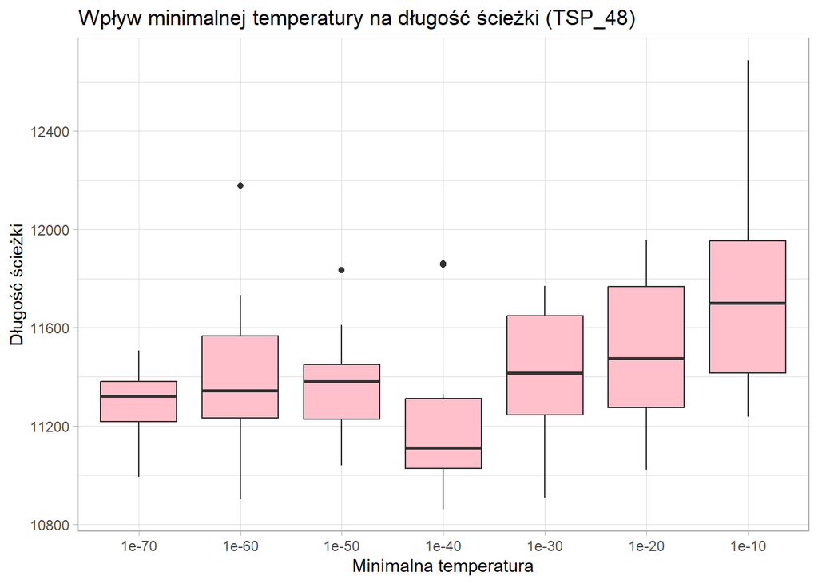

**Statystyki długości ścieżki w zależności od wartości temperatury minimalnej (TSP_48)**

| PARAMETR | Min | Max | Mean |
| --- | --- | --- | --- |
| 1e-70 | 10992 | 11507 | 11274.8 |
| 1e-60 | 10902 | 12178 | 11403.6 |
| 1e-50 | 11039 | 11833 | 11372.0 |
| 1e-40 | 10862 | 11860 | 11245.6 |
| 1e-30 | 10908 | 11769 | 11422.6 |
| 1e-20 | 11022 | 11955 | 11503.2 |
| 1e-10 | 11237 | 12689 | 11750.6 |

Wraz ze wzrostem wartości temperatury minimimalnej mediana i średnia rosną. Zbyt duża minimalna temperatura początkowa powoduje, że algorytm kończy działanie zanim zdoła osiągnąć najlepsze możliwe rozwiązania. W efekcie pozostaje na gorszych ścieżkach, co powoduje wzrost mediany i średniej długości.

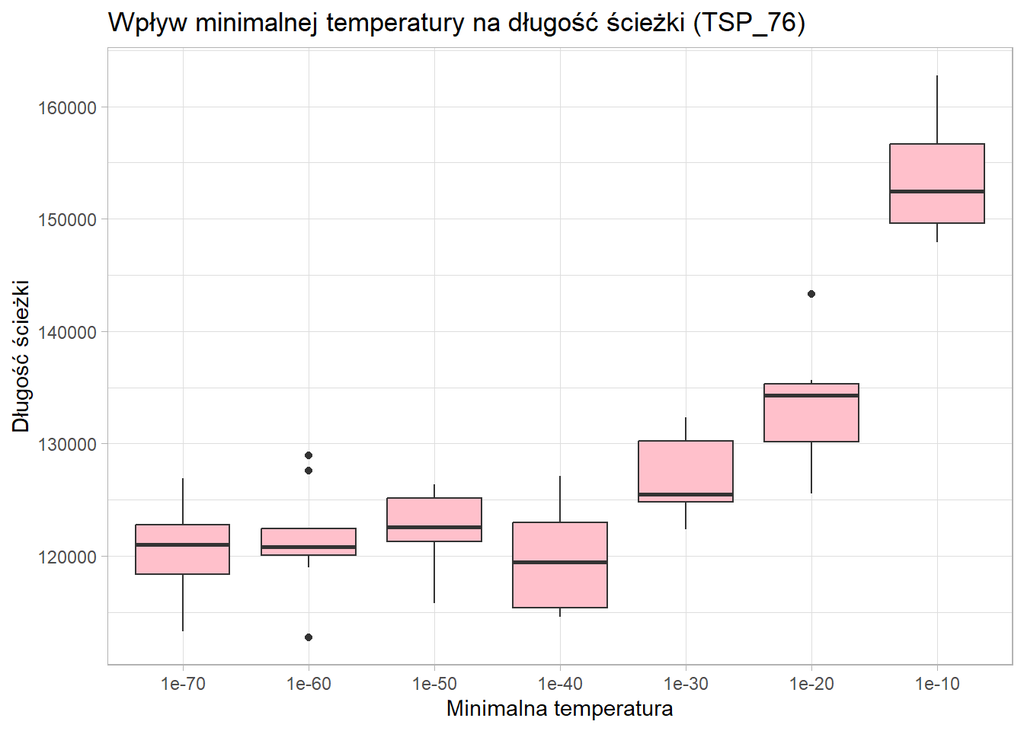

**Statystyki długości ścieżki w zależności od wartości temperatury minimalnej (TSP_76)**

| PARAMETR | Min | Max | Mean |
| --- | --- | --- | --- |
| 1e-70 | 113305.6 | 126876.3 | 120758.1 |
| 1e-60 | 112768.6 | 128937.7 | 121517.0 |
| 1e-50 | 115787.7 | 126328.7 | 122665.5 |
| 1e-40 | 114576.3 | 127087.1 | 119707.4 |
| 1e-30 | 122331.4 | 132294.2 | 126956.4 |
| 1e-20 | 125573.4 | 143273.3 | 133308.2 |
| 1e-10 | 147893.1 | 162779.7 | 153525.0 |

Tutaj pojawia się podobna sytuacja. Wraz ze wzrostem wartości minimalnej, wyniki są coraz gorsze.

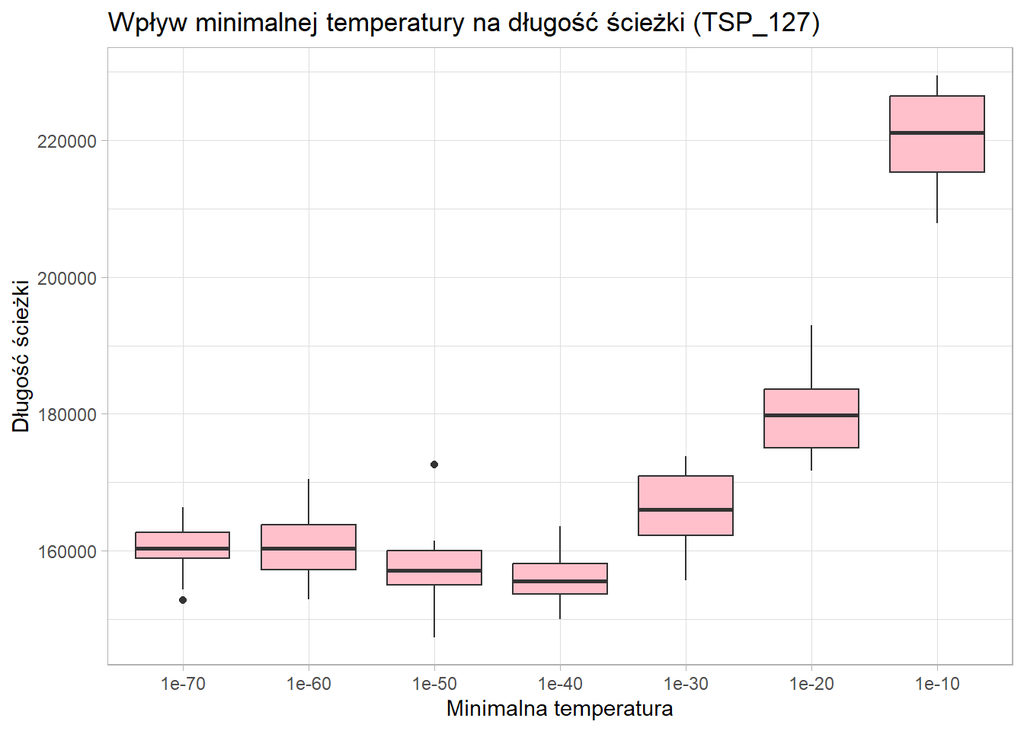

**Statystyki długości ścieżki w zależności od wartości temperatury minimalnej (TSP_127)**

| PARAMETR | Min | Max | Mean |
| --- | --- | --- | --- |
| 1e-70 | 152722.4 | 166314.9 | 160182.1 |
| 1e-60 | 152904.8 | 170459.4 | 160576.2 |
| 1e-50 | 147347.1 | 172613.1 | 157949.2 |
| 1e-40 | 149994.4 | 163597.5 | 155863.9 |
| 1e-30 | 155702.7 | 173836.8 | 166051.6 |
| 1e-20 | 171702.2 | 192907.4 | 180485.8 |
| 1e-10 | 207885.5 | 229539.5 | 220532.6 |

Dla TSP_127 sytuacja jest analogiczna.

## Podsumowanie

Dla TSP_48 przy użyciu algorytmu symulowanego wyżarzania udało się uzyskać parę lepszych wyników niż ten uzyskany przez Solver (10868).

Najlepsze wyniki dla **TSP_76** przy zmianie poszczególnych parametrów:

- `Klasyczne` - 116708.4
- `Rodzaj sąsiedztwa` - 113460.2 (rodzaj sąsiedztwa - 2-opt)
- `Temperatura początkowa` - 113094.6 (temperatura początkowa - 50 tys.)
- `Prędkość chłodzeni`a - 114398.9 (prędkość chłodzenia - 0.97)
- `Liczba iteracji` - 113809.8 (liczba iteracji - 9000)
- `Minimalna temperatura` - 112768.6 (minimalna temperatura - 1e-60)

Dla TSP_76 przy użyciu algorytmu symulowanego wyżarzania również udało się uzyskać sporo zdecydowanie lepszych wyników niż ten uzyskany przez Solver (118293.5).

Najlepsze wyniki dla **TSP_127** przy zmianie poszczególnych parametrów:

- `Klasyczne` - 147496.4
- `Rodzaj sąsiedztwa` - 148832.8 (rodzaj sąsiedztwa - 2-opt)
- `Temperatura początkowa` - 146215.7 (temperatura początkowa - 10 tys.)
- `Prędkość chłodzenia` - 143162.3 (prędkość chłodzenia - 0.98)
- `Liczba iteracji` - 148956.7 (liczba iteracji - 8000)
- `Minimalna temperatura` - 147347.1 (minimalna temperatura - 1e-50)

Dla TSP_127 przy użyciu algorytmu symulowanego wyżarzania nie udało się uzyskać lepszych wyników niż ten uzyskany przez Solver (140217.6).

# Algorytm przeszukiwania tabu (TS)

**Algorytm przeszukiwania tabu** (ang. Tabu Search, TS) to algorytm, który opiera się na stopniowym ulepszaniu początkowego, losowego rozwiązania. W przypadku problemu komiwojażera algorytm stara się skrócić trasę w taki sposób, aby odwiedzić wszystkie punkty. TS działa w sposób iteracyjny – w każdej iteracji obecne rozwiązanie jest modyfikowane poprzez wybór jednego z ruchów zdefiniowanych w sąsiedztwie. Charakterystyczną cechą algorytmu TS jest lista tabu, która przechowuje ruchy wykonane w ostatnich iteracjach. Ruchy te są czasowo zakazane, co zapobiega zapętleniu się algorytmu i ponownemu odwiedzaniu tych samych rozwiązań. Algorytm pozwala również na wykonanie ruchu, który chwilowo pogarsza rozwiązanie. Taki mechanizm umożliwia ucieczkę z lokalnych ekstremów i zwiększa szansę na znalezienie rozwiązania globalnie optymalnego lub bliskiego optymalnemu. Dodatkowo TS może korzystać z kryterium zakończenia działania, które przerywa algorytm, jeśli przez dłuższy czas nie nastąpi poprawa wyniku.

Zasada działania algorytmu przeszukiwania tabu do rozwiązania problemu komiwojażera:

1. Generowane jest początkowe rozwiązanie oraz obliczany jego koszt.
2. Inicjalizowana jest lista tabu z ograniczoną długością. Jeśli lista osiągnie maksymalną długość, najstarsze rozwiązanie zostaje z niej usunięte.
3. W każdej iteracji algorytmu generowane jest sąsiedztwo, które zawiera rozwiązania uzyskane poprzez zastosowanie jednego z trzech typów ruchów. Sąsiedztwo jest generowane na podstawie bieżącego rozwiązania.
4. Każde rozwiązanie w sąsiedztwie jest oceniane pod kątem kosztu. Spośród tych rozwiązań wybierany jest najlepszy sąsiad, który nie jest na liście tabu,a którego koszt jest mniejszy niż dotychczasowego najlepszego rozwiązania.
5. Jeżeli znaleziony najlepszy sąsiad nie jest na liście tabu, staje się on nowym rozwiązaniem bazowym i jest dodawany do listy tabu.
6. Jeśli znaleziono lepsze rozwiązanie, aktualizowane są zarówno bieżące rozwiązanie, jak i najlepsze rozwiązanie, jeśli nowe jest lepsze od dotychczasowego.
7. Algorytm kończy działanie, gdy zostanie osiągnięty limit czasu, maksymalna liczba iteracji lub maksymalna liczba iteracji bez poprawy rozwiązania.
8. Po zakończeniu działania, algorytm zwraca najlepsze znalezione rozwiązanie.

## Badane parametry

W ramach algorytmu przeszukiwania tabu badane są następujące parametry:

- **`move_type`** - rodzaj sąsiedztwa - metoda generowania nowych rozwiązań na podstawie aktualnego rozwiązania. W badaniu uwzględniono typy:
  - `swap` nowe rozwiązanie powstaje poprzez zamianę miejscami dwóch miast w bieżącej trasie
  - `insertion` polega na wyborze jednego miasta z danej trasy, usunięciu go z jego pierwotnej pozycji, a następnie wstawieniu go w inne, wybrane miejsce w tej samej trasie
  - `two-opt` wiąże się z odwróceniem segmentu trasy między dwoma wybranymi wierzchołkami, co prowadzi do zmiany kolejności miast w tym segmencie
- **`tabu_list_length`** - długość listy tabu - liczba wykonanych ruchów, które nie mogą być ponownie wykorzystanie przez określoną liczbę iteracji
- **`max_iterations`** - liczba iteracji, po której algorytm kończy działanie
- **`max_no_improve`** - liczba iteracji bez poprawy - liczba iteracji, po której algorytm kończy działanie, jeśli nie znaleziono lepszego rozwiązania
- **`time_limit`** - limit czasowy

### Klasyczne

Za podstawowe dane przyjmujemy:

- tabu_list_length = 10
- max_iterations = 10000
- max_no_improve = 50
- move_type = `two_opt`
- time_limit = 1000

| TSP_48 | TSP_76 | TSP_127 |
| --- | --- | --- |
| 11155 | 141492.6 | 229255.7 |
| 11340 | 142259.5 | 216364.8 |
| 11248 | 132999.1 | 218793.0 |
| 11482 | 134537.2 | 220065.1 |
| 11321 | 134759.5 | 207747.4 |
| 11012 | 139490.2 | 204850.2 |
| 11002 | 132623.6 | 205877.9 |
| 11145 | 139394.5 | 210516.5 |
| 11071 | 134829.1 | 207932.5 |
| 10851 | 129754.0 | 216740.0 |

|  | Min | Max | Mean |
| --- | --- | --- | --- |
| TSP_48 | 10851.0 | 11482.0 | 11162.7 |
| TSP_76 | 129754.0 | 142259.5 | 136213.9 |
| TSP_127 | 204850.2 | 229255.7 | 213814.3 |

|  | Min | Max | Mean |
| --- | --- | --- | --- |
| TSP_48 | 0.838192 | 1.085934 | 0.9591483 |
| TSP_76 | 4.149139 | 4.294834 | 4.1968106 |
| TSP_127 | 19.017783 | 19.370982 | 19.1883122 |

Średnie czasy są bardzo niskie, zwłaszcza w porównaniu do Solvera.